# Introducing Model with SIR example

### Functions

Load functions to run model, with most recent version

```r
source(here("Vfunctions", "V_stateUpdateT2.R")) # wrapper function, tracks epidemic in population over generations
source(here("Vfunctions", "V_DS_T2.R")) # updates state of population based on current generation
source(here("Vfunctions", "S_to_I_T2.R")) # infection simulation
source(here("Vfunctions", "effcIdGenT2.R")) # generating effective contact IDs
source(here("Vfunctions", "effcChecker.R")) # verifying effective contact IDs
source(here("Vfunctions", "reseedingT2.R")) # reseeding infection
```

### Parameters

**Population Parameters**

- `state_tracker` : initial state of population (vector)
- `N` : population size
- `populationSample` : “large” or “small”, determines infection sampling strategy

**Model Parameters**

- `generations` : the number of generations (timesteps) to run the model over
- `output` : defines the output as…
  - “matrix” : returns disease state and ID of units
  - “counts”: returns number of units in each disease state
  - “I_counts” : returns only count of infected units over time

**Epidemiological Parameters**

- `R_period` : the refractory period, number of timesteps that units are immune (1 = no immunity, Inf = lifelong immunity)
- `R0_estimate` : reproduction rate, average number of effective contacts per unit
- `k_transmission` : dispersion parameter for transmission rate of units (0.1 = high heterogeneity, Inf = homogeneous)
- `heterogeneity` : “fixed” or “variable”, defines whether unit contact rates are constant or change over time
- `contact_list` : list of potential contacts for each unit

**Reseeding Parameters**

- `reseed` : TRUE or FALSE, defines whether reseeding events occur
- `reseed_threshold` : threshold generation for reseeding events
- `reseed_frequency` : frequency of reseeding events (e.g. every 2 generations)
- `introductions` : the number of new cases introduced with a reseeding event

**Vaccination Parameters**

- `V_prop` : proportion of population to be vaccinated each round
- `V_start` : start generation for vaccination
- `V_period` : duration of immunity from vaccination ( number of generations)
- `V_rounds` : number of rounds of vaccination
- `V_schedule` : frequency of vaccination rounds (e.g. every 2 generations)
- `V_mode` : “random”, “target” or “non_target” vaccination strategy,
  - *NB: target/non-target are only viable if heterogeneity = fixed*

## Basic Functioning

Initial exploration of model behaviour 1. Simulate a single epidemic 2. Does the model correspond to expected behaviours? + Epidemic threshold at $R0 = 1$ + Herd Immunity at $1-1/R0$

### Test 1 : A single epidemic

Simulating a single epidemic:

#### Define Parameters

Test Model function by changing each of the following parameters in turn.

- output: matrix/counts/I_counts
- population_sample : small/large
- heterogeneity = fixed/variable

```r
## Model Definition ##
runs <- 1
generations <- 100 # the number of generations (or timesteps) to run the model over
output <- "counts" # defines the output as "matrix" (full disease state and ID of units) or "counts" (number of units in S,I,R states or "I_counts" (returns only count of infected units over time)

## PARAMETERS ##

## Population Parameters ##

N <- 10000 # population size (may exxclude in favour of calculating in state_update function)
I0 <- 10
state_tracker <- c(rep("I", I0), rep("S", N - I0)) # initial disease state of units in population
population_sample <- "large" # large or small population (determines sampling strategy)

## Epidemiological Parameters ##

R_period <- Inf # the refractory period: 1 = no immunity, Inf = lifelong immunity
R0_estimate <- 3 # average number of effective contacts per unit
k_transmission <- Inf # overdispersion parameter, level of heterogeneity in effective contact potential: 0.1 = high heterogneiety, Inf = homogeneous

heterogeneity <- "fixed" # "fixed" or "variable", is unit transmission potential constant through time?
contact_list1 <- replicate(N, c(1:N), simplify = FALSE)
contact_list <- lapply(1:length(contact_list1),
                       function(x) contact_list1[[x]][-x])

## Reseeding Parameters ##
reseed <- FALSE # reseed 5 infections periodically during the first 10% of generations
reseed_threshold <- 0# threshold generation for reseeding events
reseed_frequency <- 0
introductions <- 0 # number of new cases introduced when reseeding occurs

## Vaccination Parameters ##
V_prop <- 0 # proportion to be vaccinated in each round
V_start <- 0 # start generation for vaccination
V_period <- 0 # duration of immunity from vaccination (by number of timesteps)
V_rounds <- 0 # number of rounds (-1 for starting round) of vaccination in programme
V_schedule <- 0 # how frequent is vacciantion (ie every 2 "years")
V_mode <- "random" #random, target or non_target, NB: target/non-target only possible if heterogneiety is fixed
```

#### Run Model:

```r
Runs_tracker <-
  state_update(
    state_tracker,
    N,
    population_sample,
    generations,
    output,
    R_period,
    R0_estimate,
    k_transmission,
    heterogeneity,
    contact_list,
    reseed,
    reseed_threshold,
    reseed_frequency,
    introductions,
    V_prop,
    V_start,
    V_period,
    V_rounds,
    V_schedule,
    V_mode
  )
```

#### Plot Model:

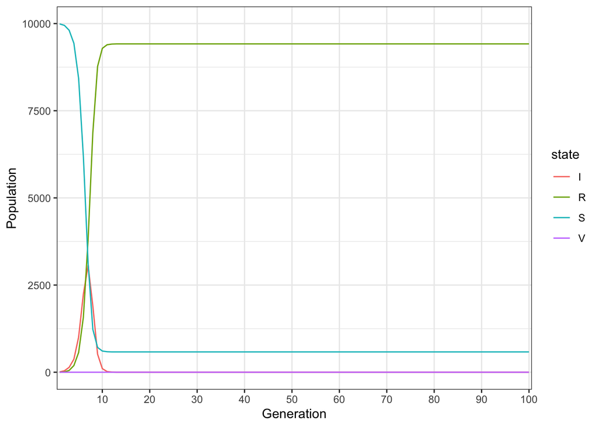

```r
    Runs_tracker$state <- c("S","I","R","V")
    Runs_long <- melt(Runs_tracker, id.var = "state")

    ggplot(data = Runs_long, aes(x = variable,y=value, group = state))+
      geom_line(aes(colour = state))+
      scale_x_discrete(breaks = seq(0,100,10))+
      xlab("Generation")+
      ylab("Population")+
      scale_fill_discrete("Disease State")+
      theme_bw()
```